# Predicting Recombination Rate with ResNet-18

In this tutorial, we demonstrate how to train a convolutional neural network (ResNet-18) to predict continuous population genetic parameters directly from binary alignment data.

### Workflow

1. **Simulation Setup**: Configure `MSPrimeSimulator` using an empirical recombination prior defined in `recom.ini`.
2. **Haplotype Alignment Transforms**: Polarize, seriate (order rows by similarity), and pad/crop alignments into fixed tensor shapes.
3. **On-the-Fly Simulation**: Wrap the simulation pipeline in `LiveSimulationDataset` to generate fresh training data continuously during training.
4. **Training**: Optimize ResNet-18 using Smooth L1 loss.
5. **Evaluation**: Compare true vs. predicted log recombination rates $\log(r)$ on holdout simulations.

We use the following config file to specify our prior:

```
[base]
mu = 1.5e-8
r = TruncatedExponential(a = 1e-8, b = 1e-6, lam = 4641167.677653745)
L = 200000
ploidy = 1

[samples]
# A diploid population with a variable size history defined by a spline
pop1 = {'N0': 'UniformFloatDiscrete([1e3, 2e3, 5e3, 1e4, 2e4, 5e4])', 'n': 32}
```

## 1. Imports and Environment Setup

```
Using device: cuda
```

## 2. Simulator Configuration & Data Preprocessing

We instantiate `MSPrimeSimulator` with `recom.ini`, compose a transformation pipeline to format alignments to fixed `(n, 128)` dimensions, and standardize the regression target $\log(r)$ using empirical prior statistics.

```
Target prior log(r): mean = -15.7791, std = 1.0152
```

## 3. Dataset & DataLoader

`LiveSimulationDataset` calls `simulator.simulate()` on demand. The `parse_fn` processes each simulation dictionary into:

- **Feature Tensor**: Haplotype matrix formatted to `(1, n_samples, 128)` for 2D convolution.
- **Label Tensor**: Standardized log recombination rate $z = \frac{\log(r) - \mu_y}{\sigma_y}$.

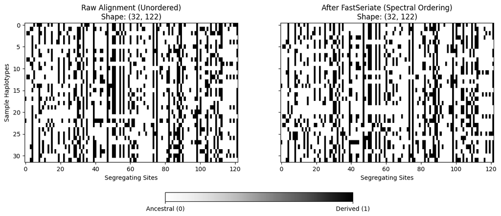

## 4. Model Architecture & Optimizer

We use a 1-channel `resnet18` adapted for single-channel genotype matrices, predicting a single scalar output ($k=1$).

```
ResNet(
  (conv1): Conv2d(1, 64, kernel_size=(7, 7), stride=(2, 2), padding=(3, 3), bias=False)
  (bn1): BatchNorm2d(64, eps=1e-05, momentum=0.1, affine=True, bias=True, track_running_stats=True)
  (relu): ReLU(inplace=True)
  (maxpool): MaxPool2d(kernel_size=3, stride=2, padding=1, dilation=1, ceil_mode=False)
  (layer1): Sequential(
    (0): BasicBlock(
      (conv1): Conv2d(64, 64, kernel_size=(3, 3), stride=(1, 1), padding=(1, 1), bias=False)
      (bn1): BatchNorm2d(64, eps=1e-05, momentum=0.1, affine=True, bias=True, track_running_stats=True)
      (relu): ReLU(inplace=True)
      (conv2): Conv2d(64, 64, kernel_size=(3, 3), stride=(1, 1), padding=(1, 1), bias=False)
      (bn2): BatchNorm2d(64, eps=1e-05, momentum=0.1, affine=True, bias=True, track_running_stats=True)
    )
    (1): BasicBlock(
      (conv1): Conv2d(64, 64, kernel_size=(3, 3), stride=(1, 1), padding=(1, 1), bias=False)
      (bn1): BatchNorm2d(64, eps=1e-05, momentum=0.1, affine=True, bias=True, track_running_stats=True)
      (relu): ReLU(inplace=True)
      (conv2): Conv2d(64, 64, kernel_size=(3, 3), stride=(1, 1), padding=(1, 1), bias=False)
      (bn2): BatchNorm2d(64, eps=1e-05, momentum=0.1, affine=True, bias=True, track_running_stats=True)
    )
  )
  (layer2): Sequential(
    (0): BasicBlock(
      (conv1): Conv2d(64, 128, kernel_size=(3, 3), stride=(2, 2), padding=(1, 1), bias=False)
      (bn1): BatchNorm2d(128, eps=1e-05, momentum=0.1, affine=True, bias=True, track_running_stats=True)
      (relu): ReLU(inplace=True)
      (conv2): Conv2d(128, 128, kernel_size=(3, 3), stride=(1, 1), padding=(1, 1), bias=False)
      (bn2): BatchNorm2d(128, eps=1e-05, momentum=0.1, affine=True, bias=True, track_running_stats=True)
      (downsample): Sequential(
        (0): Conv2d(64, 128, kernel_size=(1, 1), stride=(2, 2), bias=False)
        (1): BatchNorm2d(128, eps=1e-05, momentum=0.1, affine=True, bias=True, track_running_stats=True)
      )
    )
    (1): BasicBlock(
      (conv1): Conv2d(128, 128, kernel_size=(3, 3), stride=(1, 1), padding=(1, 1), bias=False)
      (bn1): BatchNorm2d(128, eps=1e-05, momentum=0.1, affine=True, bias=True, track_running_stats=True)
      (relu): ReLU(inplace=True)
      (conv2): Conv2d(128, 128, kernel_size=(3, 3), stride=(1, 1), padding=(1, 1), bias=False)
      (bn2): BatchNorm2d(128, eps=1e-05, momentum=0.1, affine=True, bias=True, track_running_stats=True)
    )
```

[output cut: 31 more lines]

```
      )
    )
    (1): BasicBlock(
      (conv1): Conv2d(512, 512, kernel_size=(3, 3), stride=(1, 1), padding=(1, 1), bias=False)
      (bn1): BatchNorm2d(512, eps=1e-05, momentum=0.1, affine=True, bias=True, track_running_stats=True)
      (relu): ReLU(inplace=True)
      (conv2): Conv2d(512, 512, kernel_size=(3, 3), stride=(1, 1), padding=(1, 1), bias=False)
      (bn2): BatchNorm2d(512, eps=1e-05, momentum=0.1, affine=True, bias=True, track_running_stats=True)
    )
  )
  (avgpool): AdaptiveAvgPool2d(output_size=(1, 1))
  (fc): Sequential(
    (0): Linear(in_features=512, out_features=1, bias=True)
  )
)
```

## 5. Model Training

```
Starting Training...
```

```
 20%|█████████████████████████████▌                                                                                                                      | 1/5 [01:19<05:16, 79.14s/it]
```

```
Epoch [1/5] - Loss (Smooth L1): 0.6983
```

```
 40%|███████████████████████████████████████████████████████████▏                                                                                        | 2/5 [02:18<03:22, 67.53s/it]
```

```
Epoch [2/5] - Loss (Smooth L1): 0.4352
```

```
 60%|████████████████████████████████████████████████████████████████████████████████████████▊                                                           | 3/5 [03:29<02:17, 68.99s/it]
```

```
Epoch [3/5] - Loss (Smooth L1): 0.4242
```

```
 80%|██████████████████████████████████████████████████████████████████████████████████████████████████████████████████████▍                             | 4/5 [04:17<01:00, 60.61s/it]
```

```
Epoch [4/5] - Loss (Smooth L1): 0.3517
```

```
100%|████████████████████████████████████████████████████████████████████████████████████████████████████████████████████████████████████████████████████| 5/5 [05:27<00:00, 65.47s/it]
```

```
Epoch [5/5] - Loss (Smooth L1): 0.3563
```

## 6. Visualizing Training Loss & Validation Performance

We plot the training loss progression alongside a scatter plot of true versus predicted recombination rates on a holdout batch, unstandardized back to natural log space $\log(r)$.

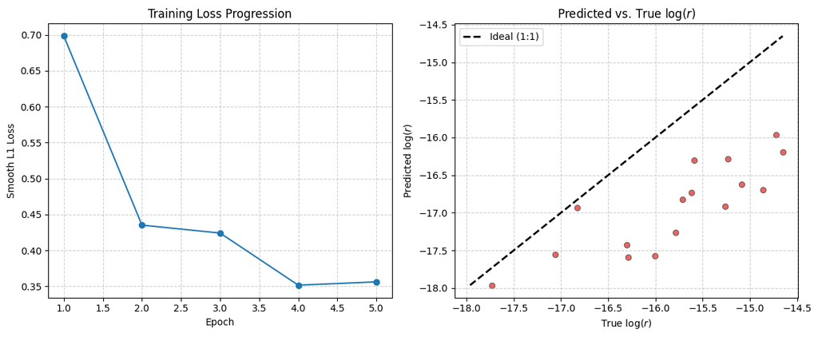